# House Price Prediction (1)

```python
import numpy as np
import pandas as pd
import seaborn as sb
import matplotlib.pyplot as plt

%matplotlib inline
```

```python
df = pd.read_csv('house_prices.csv')
print(df.shape)
df.head()
```

```
(6028, 7)
```

|  | house_id | neighborhood | area | bedrooms | bathrooms | style | price |
| --- | --- | --- | --- | --- | --- | --- | --- |
| 0 | 1112 | B | 1188 | 3 | 2 | ranch | 598291 |
| 1 | 491 | B | 3512 | 5 | 3 | victorian | 1744259 |
| 2 | 5952 | B | 1134 | 3 | 2 | ranch | 571669 |
| 3 | 3525 | A | 1940 | 4 | 2 | ranch | 493675 |
| 4 | 5108 | B | 2208 | 6 | 4 | victorian | 1101539 |

```python
df.dtypes
```

```
house_id         int64
neighborhood    object
area             int64
bedrooms         int64
bathrooms        int64
style           object
price            int64
dtype: object
```

```python
# lets convert the house id into a string because it will not be used for any computations
df['house_id'] = df['house_id'].astype(str)
```

```python
df.describe()
```

|  | area | bedrooms | bathrooms | price |
| --- | --- | --- | --- | --- |
| count | 6028.000000 | 6028.000000 | 6028.000000 | 6.028000e+03 |
| mean | 2136.849038 | 3.717651 | 2.158261 | 7.542079e+05 |
| std | 1237.481101 | 1.704650 | 1.169621 | 5.236731e+05 |
| min | 0.000000 | 0.000000 | 0.000000 | 1.216700e+04 |
| 25% | 1225.000000 | 3.000000 | 2.000000 | 3.641350e+05 |
| 50% | 1826.000000 | 4.000000 | 2.000000 | 6.357590e+05 |
| 75% | 3129.000000 | 5.000000 | 3.000000 | 9.666752e+05 |
| max | 7447.000000 | 8.000000 | 5.000000 | 3.684602e+06 |

### Feature(s) of interest

The features I am interested most are those features best for predicting price price of the house in the dataset. I expect that area, bedrooms and bathrooms will have strong effect on the prediction, the bigger the area the higher the number of bedrooms and bathrooms as well as the price of the house, also, as the number of bedrooms and bathrooms increase, the price should increase. I also think that the neighborhood and the house style should have effect on the price.

### Univariate Exploration

I will start the univariate exploration by taking a look at the distribution of the price as the main variable of interest.

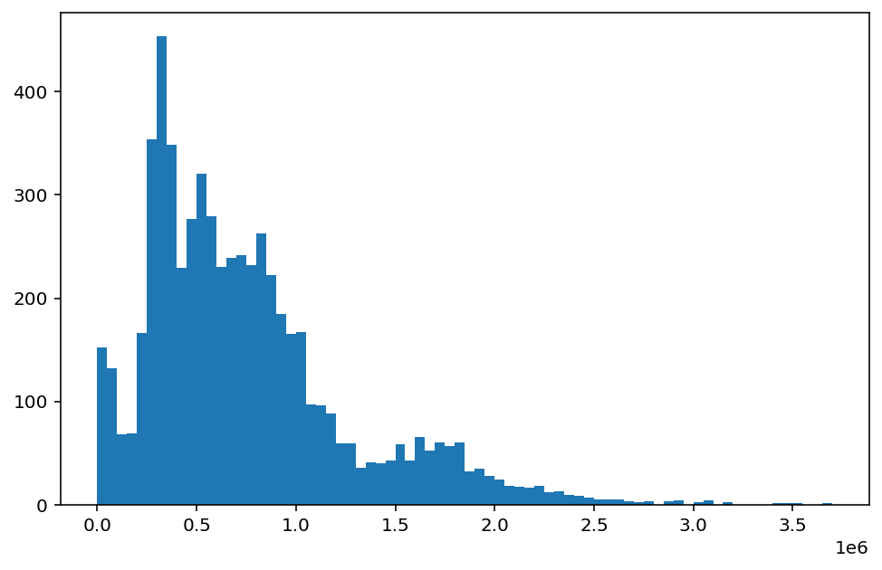

```python
# I calculated the bin size using df['price'].max() - df['price'].min() and divided by the square-root of the number of entries.
bin_size = 50000
bins = np.arange(0, df['price'].max() + bin_size, bin_size)
plt.figure(figsize = [8, 5])
plt.hist(data = df, x = 'price', bins = bins)
plt.show();
```

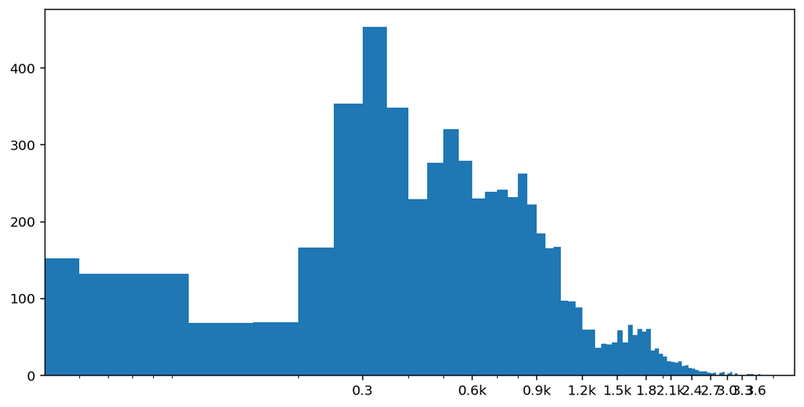

```python
bins = np.arange(0, df['price'].max() + bin_size, bin_size)
plt.figure(figsize = [10, 5])
plt.hist(data = df, x = 'price', bins = bins)
plt.xscale('log')
plt.xticks([3e5, 6e5, 9e5, 1.2e6, 1.5e6, 1.8e6, 2.1e6, 2.4e6, 2.7e6, 3.0e6, 3.3e6, 3.6e6], ['0.3', '0.6k', '0.9k', '1.2k', '1.5k', '1.8','2.1k', '2.4', '2.7', '3.0', '3.3', '3.6'])
plt.show();
```

#### Variable of Interest

Price in the above histogram has a long-tailed distribution, most of the houses are on the low price end, and few on the high price end. The price distribution looks roughly multimodal, with one peak between 0.0 and .02, the second peak a little below 0.5 and the last between 1.5 and 2.0.

###### Next: Explore the first predictor variable (Area)

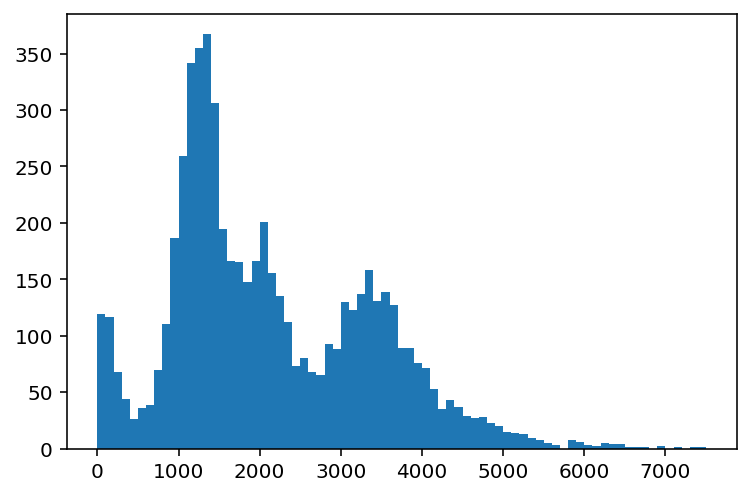

```python
bins = np.arange(0, df['area'].max() + 100, 100)
plt.hist(data = df, x = 'area', bins = bins);
```

The distribution of the area of the houses also seems to be multimodal with most of the areas between 1000 and 2500 having the first peak between 0 and 500. The second peak between 1000 and 2500 and the last one between 3000 and 4000.

#### Next Explore number of bedrooms

in the next cell the distribution of the bedrooms will be explored, to see visually how it is distributed.

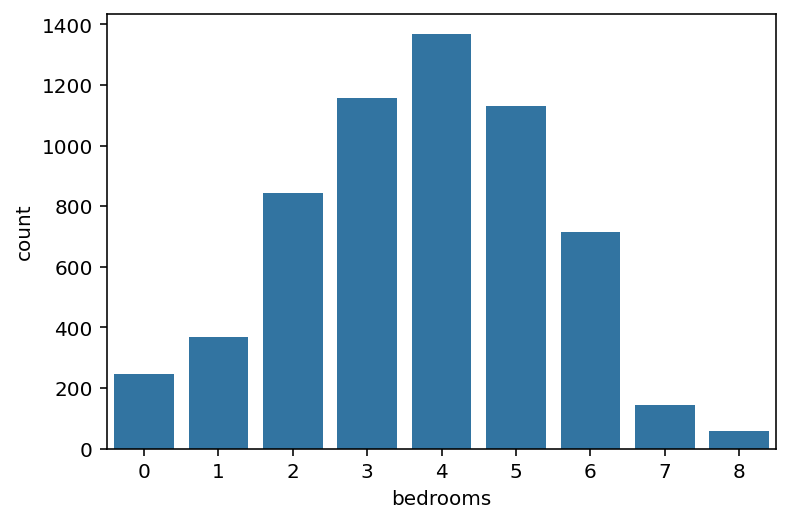

```python
base_color = sb.color_palette()[0]
sb.countplot(data = df, x = 'bedrooms', color = base_color);
```

The number of bedrooms seems to be almost normally distributed, with high concentration between 2 to 6 bedrooms, great percentage of the houses are situated there.

### Style and Neighborhood Distribution

Now I want to look at the distribution of the houses base on style and neighborhood.

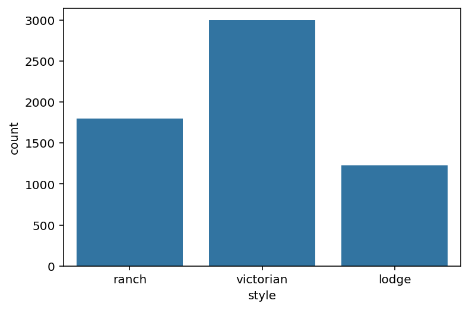

```python
sb.countplot(data = df, x = 'style', color = base_color);
```

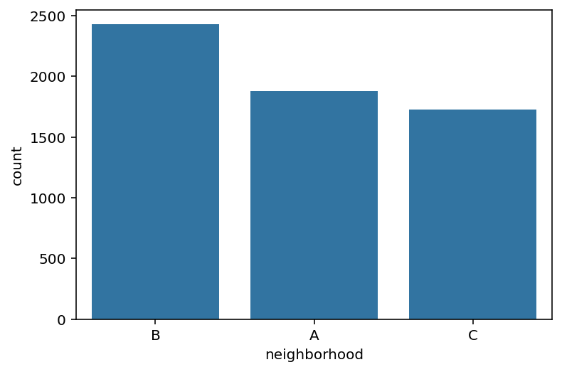

```python
sb.countplot(data = df, x ='neighborhood', color = base_color);
```

### Neighborhood

Majority of the houses are located in the B neighborhood, then followed by A and C with are having closer frequencies than B.

## Variable of Interest (Price)

The range values of the variable of interest is large, so I looked at the data using a log transform. Under the transformation, the modality of the data did not changed, the peaks are still the same as before. In the dataframe I converted the variable house_id of type int to type string, because house_id is not an important feature for prediction, we cannot perform any computations with, it was just there to identify a house as it is unique.

## Bivariate Exploration

I will start by taking a look at the correlation between price and the other variables by using the seaborn feature of pairgrid

#### Price and Numerical variables

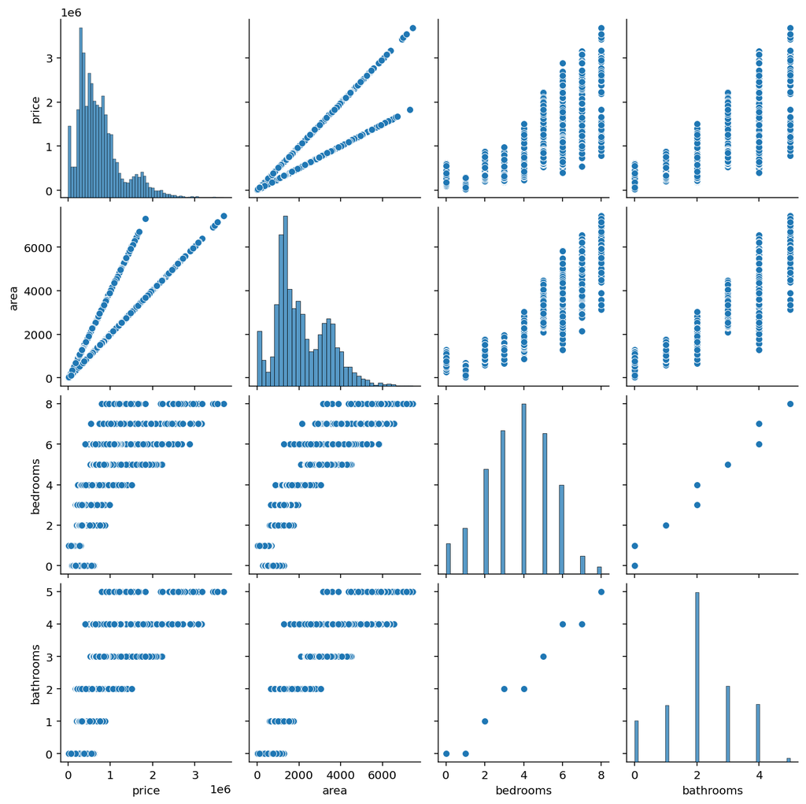

```python
g = sb.pairplot(data = df, vars = ['price', 'area', 'bedrooms', 'bathrooms' ])
g = g.map(plt.hist, bins = 20)
g.map_offdiag(plt.scatter);
```

As I expected, the area is correlated to area, bedrooms and bathrooms, area is also highly correlated with bedrooms and bathrooms. As expected, the bigger the area the higher the number of bedrooms and bathrooms as well as the price of the house, also, as the number of bedrooms and bathrooms increase, the price also increase.

#### Price and Categorical variables

I am now going to look at the relationship between price and neighborhood as well as price and house style using seabon's boxplot

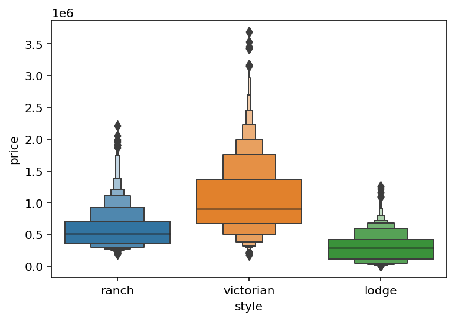

```python
sb.boxenplot(data = df, x = 'style', y = 'price');
```

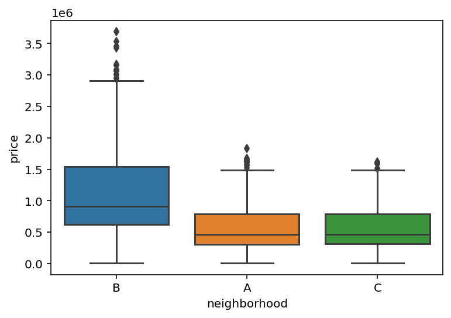

```python
sb.boxplot(data =df, x = 'neighborhood', y = 'price')
```

### Style

It appears the houses with victorian style turn out to have higher prices than other styles (ranch and lodge).

### Neighborhood

The houses in the neighborhood B have higher prices than others.

Now, lets take a look at the relationship between the two categorical variables (style and neighborhood)

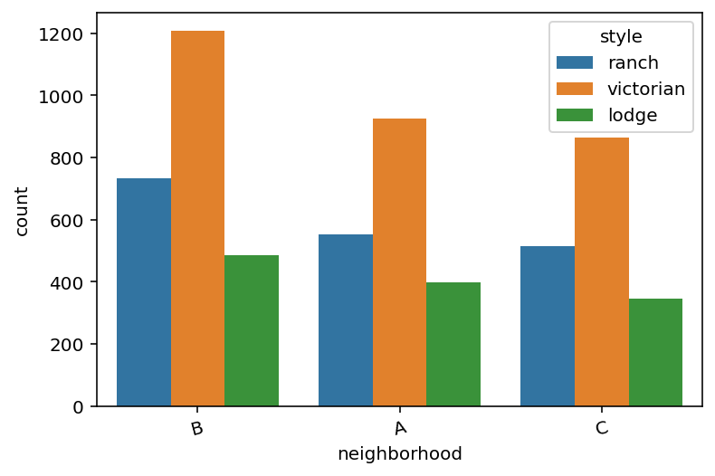

```python
sb.countplot(data = df, x = 'neighborhood' , hue = 'style')
plt.xticks(rotation = 15);
```

In the above bar chart, it can be seen that in the neighborhood B, victorian style houses has the highest number, followed by the ranch and then lodge, likewise in the neighborhood A and C respectively.

The price found to be of high amount of correlation with the area and the number of bedroom and bathrooms. the number of bedrooms is also of linear relationship with the number of bathrooms. the area of the houses has a similar relationship with both number of bedrooms and bathrooms.

### Multivariate Exploration

Here we are going to explore how the categorical variables (style and neighborhood) relate to price and the area and number of bedroooms.

### Price, area and neighborhood

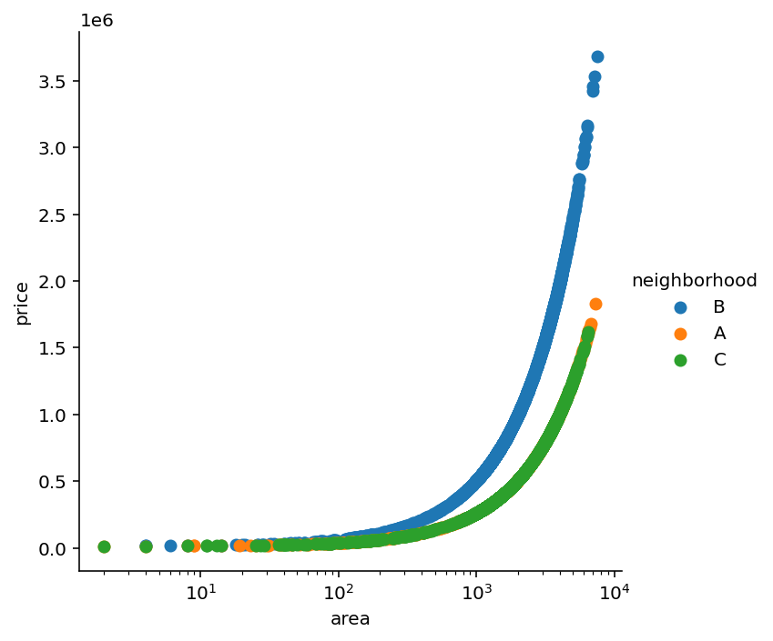

```python
g = sb.FacetGrid(data = df, hue = 'neighborhood', size = 5)
g.map(plt.scatter, 'area','price')
g.set(xscale = 'log') # need to set scaling before customizing ticks
g.add_legend();
```

### Price, area and Style

[figure not shown]

```python
g = sb.FacetGrid(data = df, hue = 'style', size = 5)
g.map(plt.scatter, 'area','price')
g.set(xscale = 'log') # need to set scaling before customizing ticks
g.add_legend();
```

In both above facetGrids, you can see the relationship of neighborhood and style level against price and house area (size). It can be seen that, in the first grid, neighborhood B has great effect on the price of a house with regard to size, because houses of the same size turn out to be more expensive in neighborhood B than A and C. While neighborhood A and C don't have much differences.

### Price, Neighborhood and bedroom

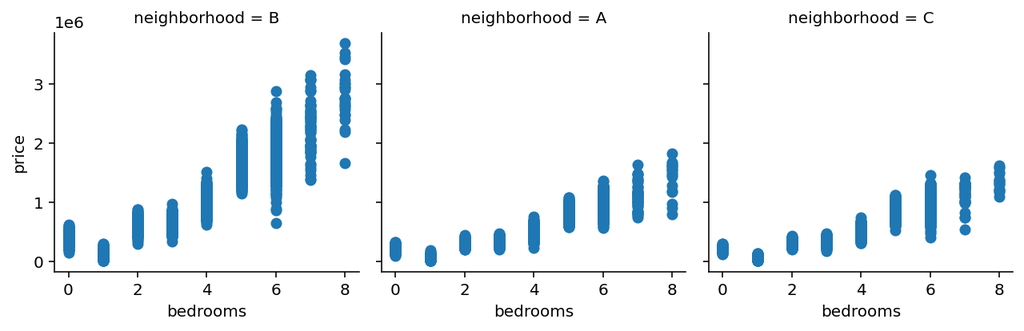

```python
g = sb.FacetGrid(data = df, col = 'neighborhood')
g.map(plt.scatter, 'bedrooms', 'price');
```

### Price, Style and Bedroom

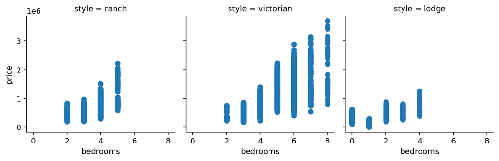

```python
g = sb.FacetGrid(data = df, col = 'style')
g.map(plt.scatter, 'bedrooms', 'price');
```

### Price, Style and Neighborhood

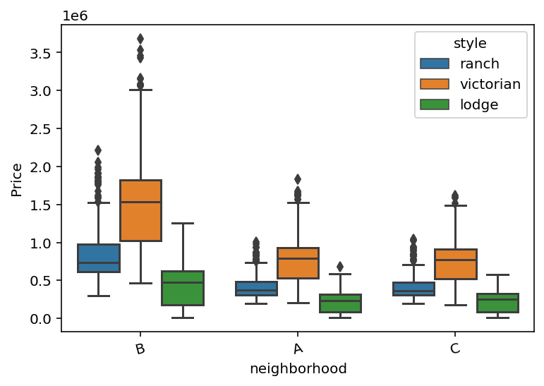

```python
sb.boxplot(data = df, x = 'neighborhood', y = 'price', hue = 'style')
plt.xticks(rotation = 15)
plt.ylabel('Price')
```

In the above boxplot, it appears in all the neighborhoods, the victorian style houses are much more expensive than other styles, and logdes are always the least expensive.